# WA Partial Least Squares

### 1. Comparison of transfer functions

**1).Reconstruct pH from diatom data from Round Loch of Glenhead**

```r
#Data extraction
data(SWAP)
data(RLGH)
ph <- SWAP[[2]]
mod.spec <- SWAP[[1]]
fossil.spec <- RLGH[[1]]
depth <- RLGH[[2]]
#Convert to proportions
mod.spec <- mod.spec/rowSums(mod.spec)
fossil.spc <- fossil.spec/rowSums(fossil.spec)
#Weighted averaging model
ph.wa <- rioja::WA(sqrt(mod.spec), ph, lean = FALSE)
ph.wa.cal <- rioja::crossval(ph.wa, method = "lgo")
#MAT NEED TO SEE HOW TO EVALUATE THE MODEL, RMSEP?
ph.mat <- rioja::MAT(sqrt(mod.spec), ph, lean = FALSE)
ph.mat.cal <- rioja::crossval(ph.mat, method = "lgo")
#Using weighted averaging partial least squares
ph.wapls <- WAPLS(sqrt(mod.spec), ph)
ph.wapls.cal <- rioja::crossval(ph.wapls)
#Evaluate models (WA, MAT, WAPLS)
ph.mat.cal
ph.wa.cal
ph.wapls.cal
```

[output not shown]

**2). Compare the reconstructions (using plots)**

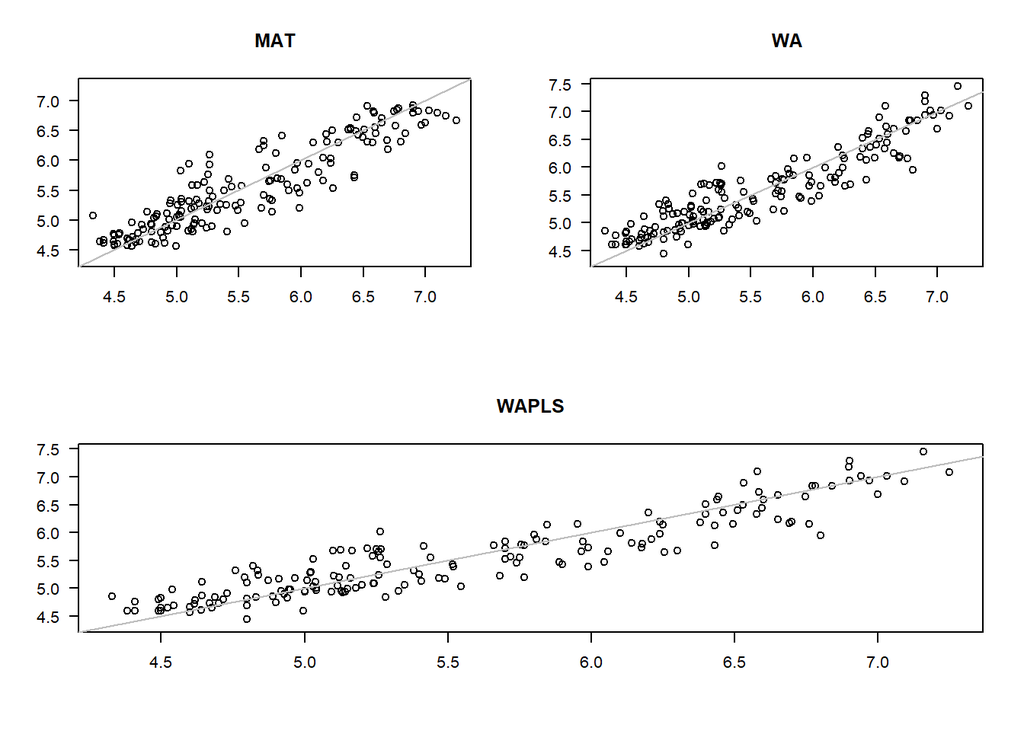

```r
#Scatter plots
layout(matrix(c(1,2,1,2,3,3,3,3), byrow = TRUE, ncol = 2))
plot(ph.mat.cal, main = "MAT")
plot(ph.wa.cal, main = "WA")
plot(ph.wapls.cal, main = "WAPLS")
```

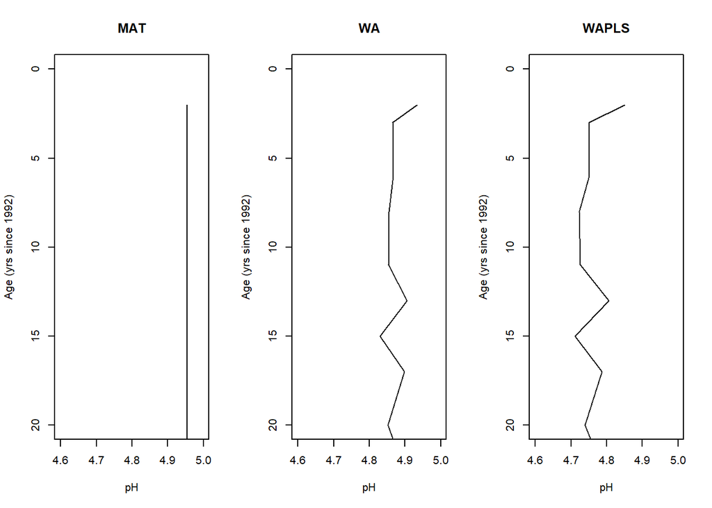

```r
#Time series plots
ph.mat.pred <- predict(ph.mat.cal, sqrt(fossil.spec))
ph.wa.pred <- predict(ph.wa.cal, sqrt(fossil.spec))
ph.wapls.pred <- predict(ph.wapls.cal, sqrt(fossil.spec))

layout(matrix(c(1,1,2,2,3,3), byrow = FALSE, ncol = 3))
plot(depth$Age ~ ph.mat.pred$fit[,1], main = "MAT", ylim = c(20,0), ylab = "Age (yrs since 1992)", xlab = "pH", type = 'l', xlim = c(4.6, 5))
plot(depth$Age ~ ph.wa.pred$fit[,1], main = "WA", ylim = c(20,0), ylab = "Age (yrs since 1992)",  xlab = "pH", type = 'l', xlim = c(4.6, 5))
plot(depth$Age ~ ph.wapls.pred$fit[,2], main = "WAPLS", ylim = c(20,0), ylab = "Age (yrs since 1992)", xlab = "pH", type = 'l', xlim = c(4.6, 5))
```

The WA and WAPLS models appear to show similar trends, but with reconstructed pH being consistently slightly lower for the WAPLS model (likely because components which were overfit to the training set were removed from the WAPLS model). The MAT model did not show much change; this lack of demonstrated trends in spite of changes in the species assemblages were likely due to the assemblages being too dissimilar to the assemblages in the training set.

**3). Calculate correlations among the three reconstructions**

```r
mods.cor <- data.frame(ph.mat.pred$fit[,1], ph.wa.pred$fit[,1], ph.wapls.pred$fit[,2])
colnames(mods.cor) <- c("MAT", "WA", "WAPLS")
cor(mods.cor)
```

```
##             MAT        WA     WAPLS
## MAT   1.0000000 0.8467891 0.8290459
## WA    0.8467891 1.0000000 0.9959133
## WAPLS 0.8290459 0.9959133 1.0000000
```

WA and WAPLS are very highly correlated with each other and both similarly less so with MAT.

**4). How many analogues does MAT use?**

```r
ph.mat.cal
```

```
##
## Method : Modern Analogue Technique
## Call   : MAT(y = y, x = x, dist.method = "sq.chord", k = 5, lean = FALSE)
##
## Distance : sq.chord
## No. samples        : 167
## No. species        : 277
## Cross val.         : lgo : no. groups =  10
##
##
## Performance:
##                RMSE      R2  Avg.Bias  Max.Bias    Skill
## N01          0.4037  0.7514   -0.0051    0.3722  72.4733
## N02          0.3590  0.7907   -0.0035    0.3562  78.2375
## N03          0.3375  0.8105    0.0114    0.3593  80.7599
## N04          0.3223  0.8256    0.0167    0.3693  82.4579
## N05          0.3131  0.8352    0.0144    0.3729  83.4479
## N01.wm       0.4037  0.7514   -0.0051    0.3722  72.4733
## N02.wm       0.3583  0.7916   -0.0028    0.3600  78.3216
## N03.wm       0.3362  0.8120    0.0109    0.3642  80.9111
## N04.wm       0.3211  0.8270    0.0158    0.3712  82.5922
## N05.wm       0.3123  0.8360    0.0137    0.3741  83.5274
## N01_XVal     0.4026  0.7510    0.0058    0.4072  72.6275
## N02_XVal     0.3534  0.7963   -0.0082    0.3873  78.9124
## N03_XVal     0.3413  0.8059    0.0150    0.3848  80.3318
## N04_XVal     0.3339  0.8134    0.0202    0.4030  81.1763
## N05_XVal     0.3191  0.8294    0.0236    0.3739  82.8085
## N01.wm_XVal  0.4026  0.7510    0.0058    0.4072  72.6275
## N02.wm_XVal  0.3524  0.7974   -0.0076    0.3930  79.0294
## N03.wm_XVal  0.3395  0.8080    0.0142    0.3918  80.5339
## N04.wm_XVal  0.3318  0.8157    0.0189    0.4054  81.4099
## N05.wm_XVal  0.3177  0.8308    0.0222    0.3787  82.9559
```

5 (k = 5)

### 2. Spatial autocorrelation

**Run and cross-validate MAT and WA transfer functions for July temp and July sunshine**

```r
#MAT temp
mod.pollen <- arctic.pollen/rowSums(arctic.pollen)
temp.mat <- rioja::MAT(sqrt(mod.pollen), arctic.env$tjul, lean = FALSE, k = 5)
temp.mat.cal <- rioja::crossval(temp.mat)
#MAT sun
sun.mat <- rioja::MAT(sqrt(mod.pollen), arctic.env$sjul, lean = FALSE, k = 5)
sun.mat.cal <- rioja::crossval(sun.mat)

#WA temp
temp.wa <- rioja::WA(sqrt(mod.pollen), arctic.env$tjul, lean = FALSE)
temp.wa.cal <- rioja::crossval(temp.wa)
#WA sun
sun.wa <- rioja::WA(sqrt(mod.pollen), arctic.env$sjul, lean = FALSE)
sun.wa.cal <- rioja::crossval(sun.wa)
```

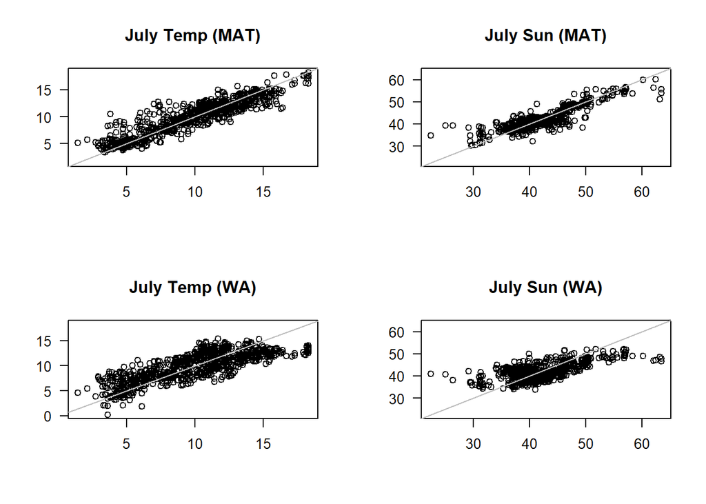

```r
layout(matrix(c(1,2,3,4), byrow = TRUE, ncol = 2))
plot(temp.mat.cal, main = "July Temp (MAT)")
plot(sun.mat.cal, main = "July Sun (MAT)")
plot(temp.wa.cal, main = "July Temp (WA)")
plot(sun.wa.cal, main = "July Sun (WA)")
```

```r
temp.mat.cal
```

```
##
## Method : Modern Analogue Technique
## Call   : MAT(y = y, x = x, dist.method = "sq.chord", k = 5, lean = FALSE)
##
## Distance : sq.chord
## No. samples        : 828
## No. species        : 39
## Cross val.         : lgo : no. groups =  10
##
##
## Performance:
##                RMSE      R2  Avg.Bias  Max.Bias    Skill
## N01          1.7287  0.7712   -0.0597    1.7667  76.1835
## N02          1.6016  0.7977   -0.0189    1.6238  79.5564
## N03          1.4409  0.8349   -0.0512    1.8778  83.4530
## N04          1.4073  0.8424   -0.0485    2.1583  84.2142
## N05          1.4035  0.8434   -0.0499    2.5567  84.3004
## N01.wm       1.7287  0.7712   -0.0597    1.7667  76.1835
## N02.wm       1.5840  0.8019   -0.0266    1.6189  80.0030
## N03.wm       1.4282  0.8378   -0.0552    1.6681  83.7431
## N04.wm       1.3928  0.8457   -0.0555    1.9112  84.5396
## N05.wm       1.3858  0.8474   -0.0561    2.2720  84.6933
## N01_XVal     1.7768  0.7617   -0.0537    1.7405  74.8377
## N02_XVal     1.5739  0.8045   -0.0194    1.5381  80.2564
## N03_XVal     1.4468  0.8335   -0.0496    1.5444  83.3159
## N04_XVal     1.4077  0.8424   -0.0582    2.0667  84.2057
## N05_XVal     1.4206  0.8396   -0.0474    2.4733  83.9151
## N01.wm_XVal  1.7768  0.7617   -0.0537    1.7405  74.8377
## N02.wm_XVal  1.5661  0.8065   -0.0281    1.5319  80.4531
## N03.wm_XVal  1.4392  0.8353   -0.0579    1.4405  83.4910
## N04.wm_XVal  1.3990  0.8444   -0.0638    1.8108  84.4016
## N05.wm_XVal  1.4040  0.8433   -0.0546    2.1799  84.2892
```

```r
temp.wa.cal
```

```
##
## Method : Weighted Averaging
## Call   : rioja::WA(y = sqrt(mod.pollen), x = arctic.env$tjul, lean = FALSE)
##
## Tolerance DW       : No
## Monotonic deshrink : No
## No. samples        : 828
## No. species        : 39
## Cross val.         : loo
##
## Deshrinking regression coefficients:
##       Inverse d/s Classical d/s
## wa.b0    -29.6873        8.1298
## wa.b1      4.1067        0.1526
##
## Performance:
##                RMSE      R2  Avg.Bias  Max.Bias    Skill
## WA.inv       2.1638  0.6268    0.0000    5.1059  62.6822
## WA.cla       2.7331  0.6268    0.0000    3.3542  40.4652
## WA.inv_XVal  2.1798  0.6213    0.0014    5.1973  62.1314
## WA.cla_XVal  2.7454  0.6220    0.0034    3.4975  39.9255
```

```r
sun.mat.cal
```

```
##
## Method : Modern Analogue Technique
## Call   : MAT(y = y, x = x, dist.method = "sq.chord", k = 5, lean = FALSE)
##
## Distance : sq.chord
## No. samples        : 828
## No. species        : 39
## Cross val.         : lgo : no. groups =  10
##
##
## Performance:
##                RMSE      R2  Avg.Bias  Max.Bias    Skill
## N01          2.8690  0.7203    0.1054   14.4667  70.2774
## N02          2.4721  0.7810    0.0818   13.2500  77.9328
## N03          2.3996  0.7925    0.0684   13.3444  79.2079
## N04          2.3625  0.7989    0.1001   13.1750  79.8449
## N05          2.3250  0.8057    0.0933   13.1533  80.4802
## N01.wm       2.8690  0.7203    0.1054   14.4667  70.2774
## N02.wm       2.4478  0.7849    0.0809   13.2127  78.3644
## N03.wm       2.3633  0.7986    0.0610   13.2949  79.8317
## N04.wm       2.3312  0.8041    0.0907   13.1619  80.3757
## N05.wm       2.2976  0.8101    0.0889   13.1309  80.9381
## N01_XVal     2.8685  0.7193    0.0460   14.4667  70.2863
## N02_XVal     2.5690  0.7643    0.0617   13.2500  76.1677
## N03_XVal     2.5120  0.7728    0.0845   13.3444  77.2134
## N04_XVal     2.4129  0.7902    0.1004   13.1750  78.9763
## N05_XVal     2.4136  0.7909    0.1329   13.1533  78.9638
## N01.wm_XVal  2.8685  0.7193    0.0460   14.4667  70.2863
## N02.wm_XVal  2.5429  0.7685    0.0602   13.2127  76.6501
## N03.wm_XVal  2.4695  0.7803    0.0722   13.2949  77.9787
## N04.wm_XVal  2.3793  0.7959    0.0848   13.1619  79.5569
## N05.wm_XVal  2.3717  0.7979    0.1160   13.1309  79.6888
```

```r
sun.wa.cal
```

```
##
## Method : Weighted Averaging
## Call   : rioja::WA(y = sqrt(mod.pollen), x = arctic.env$sjul, lean = FALSE)
##
## Tolerance DW       : No
## Monotonic deshrink : No
## No. samples        : 828
## No. species        : 39
## Cross val.         : loo
##
## Deshrinking regression coefficients:
##       Inverse d/s Classical d/s
## wa.b0   -409.7605       40.3742
## wa.b1     10.7712        0.0370
##
## Performance:
##                RMSE      R2  Avg.Bias  Max.Bias     Skill
## WA.inv       4.0795  0.3990    0.0000   15.2938   39.9025
## WA.cla       6.4582  0.3990    0.0000   12.4318  -50.6110
## WA.inv_XVal  4.1618  0.3747    0.0008   15.6566   37.4552
## WA.cla_XVal  6.4974  0.3764   -0.0023   13.3350  -52.4456
```

**Use random data to train the transfer function (and compare it to the TA’s trained on July temp and July sunshine)**

```r
wa.rand <- list()
for(i in 1:999) {
  wa.rand[[i]] <- rioja::WA(sqrt(mod.pollen), runif(nrow(arctic.pollen),0,1))
} #Run random WA for climate variables 999 times
wa.rand.cal <- list()
for (i in 1:15) {
  wa.rand.cal[[i]] <- rioja::crossval(wa.rand[[i]])
} #Cross-validate - would take too long to do all of them, so we will just do 15 instead

mat.rand <- list()
for(i in 1:20) {
  mat.rand[[i]] <- rioja::MAT(sqrt(mod.pollen), runif(nrow(arctic.pollen),0,1), lean = FALSE)
} #Run random MAT for climate variables 999 times (actually, it takes too long so I will just do 20)
```

[output not shown]

```r
mat.rand.cal <- list()
for (i in 1:15) {
  mat.rand.cal[[i]] <- rioja::crossval(mat.rand[[i]])
} #Cross-validate - would take too long to do all of them, so we will just do 15 instead

#Compare random data transfer functions to real data transfer functions
```

```r
summary(temp.mat.cal)
```

```
##
## Method : Modern Analogue Technique
## Call   : MAT(y = y, x = x, dist.method = "sq.chord", k = 5, lean = FALSE)
##
## Distance : sq.chord
## No. samples        : 828
## No. species        : 39
## Cross val.         : lgo : no. groups =  10
##
##
## Performance:
##                RMSE      R2  Avg.Bias  Max.Bias    Skill
## N01          1.7287  0.7712   -0.0597    1.7667  76.1835
## N02          1.6016  0.7977   -0.0189    1.6238  79.5564
## N03          1.4409  0.8349   -0.0512    1.8778  83.4530
## N04          1.4073  0.8424   -0.0485    2.1583  84.2142
## N05          1.4035  0.8434   -0.0499    2.5567  84.3004
## N01.wm       1.7287  0.7712   -0.0597    1.7667  76.1835
## N02.wm       1.5840  0.8019   -0.0266    1.6189  80.0030
## N03.wm       1.4282  0.8378   -0.0552    1.6681  83.7431
## N04.wm       1.3928  0.8457   -0.0555    1.9112  84.5396
## N05.wm       1.3858  0.8474   -0.0561    2.2720  84.6933
## N01_XVal     1.7768  0.7617   -0.0537    1.7405  74.8377
## N02_XVal     1.5739  0.8045   -0.0194    1.5381  80.2564
## N03_XVal     1.4468  0.8335   -0.0496    1.5444  83.3159
## N04_XVal     1.4077  0.8424   -0.0582    2.0667  84.2057
## N05_XVal     1.4206  0.8396   -0.0474    2.4733  83.9151
## N01.wm_XVal  1.7768  0.7617   -0.0537    1.7405  74.8377
## N02.wm_XVal  1.5661  0.8065   -0.0281    1.5319  80.4531
## N03.wm_XVal  1.4392  0.8353   -0.0579    1.4405  83.4910
## N04.wm_XVal  1.3990  0.8444   -0.0638    1.8108  84.4016
## N05.wm_XVal  1.4040  0.8433   -0.0546    2.1799  84.2892
##
##
## Fitted values
##      N01   N02       N03    N04   N05 N01.wm    N02.wm    N03.wm    N04.wm
## 1    9.1  9.15  9.266667  8.300  8.94    9.1  9.146751  9.255821  8.350275
## 2    5.4  5.90  6.266667  5.625  5.74    5.4  5.895296  6.237800  5.756979
## 3    5.4  5.35  5.900000  5.600  5.76    5.4  5.350070  5.888344  5.628168
## .      .     .         .      .     .      .         .         .         .
## .      .     .         .      .     .      .         .         .         .
## 828 11.2 11.40 10.166667 10.550 10.12   11.2 11.391468 10.248446 10.585712
##        N05.wm
## 1    8.898891
## 2    5.827278
## 3    5.766451
## .           .
## .           .
## 828 10.199869
```

```r
summary(sun.mat.cal)
```

```
##
## Method : Modern Analogue Technique
## Call   : MAT(y = y, x = x, dist.method = "sq.chord", k = 5, lean = FALSE)
##
## Distance : sq.chord
## No. samples        : 828
## No. species        : 39
## Cross val.         : lgo : no. groups =  10
##
##
## Performance:
##                RMSE      R2  Avg.Bias  Max.Bias    Skill
## N01          2.8690  0.7203    0.1054   14.4667  70.2774
## N02          2.4721  0.7810    0.0818   13.2500  77.9328
## N03          2.3996  0.7925    0.0684   13.3444  79.2079
## N04          2.3625  0.7989    0.1001   13.1750  79.8449
## N05          2.3250  0.8057    0.0933   13.1533  80.4802
## N01.wm       2.8690  0.7203    0.1054   14.4667  70.2774
## N02.wm       2.4478  0.7849    0.0809   13.2127  78.3644
## N03.wm       2.3633  0.7986    0.0610   13.2949  79.8317
## N04.wm       2.3312  0.8041    0.0907   13.1619  80.3757
## N05.wm       2.2976  0.8101    0.0889   13.1309  80.9381
## N01_XVal     2.8685  0.7193    0.0460   14.4667  70.2863
## N02_XVal     2.5690  0.7643    0.0617   13.2500  76.1677
## N03_XVal     2.5120  0.7728    0.0845   13.3444  77.2134
## N04_XVal     2.4129  0.7902    0.1004   13.1750  78.9763
## N05_XVal     2.4136  0.7909    0.1329   13.1533  78.9638
## N01.wm_XVal  2.8685  0.7193    0.0460   14.4667  70.2863
## N02.wm_XVal  2.5429  0.7685    0.0602   13.2127  76.6501
## N03.wm_XVal  2.4695  0.7803    0.0722   13.2949  77.9787
## N04.wm_XVal  2.3793  0.7959    0.0848   13.1619  79.5569
## N05.wm_XVal  2.3717  0.7979    0.1160   13.1309  79.6888
##
##
## Fitted values
##      N01   N02      N03    N04   N05 N01.wm   N02.wm   N03.wm   N04.wm
## 1   37.4 37.15 37.06667 38.625 38.36   37.4 37.16624 37.08404 38.54387
## 2   36.7 36.85 37.36667 36.825 38.24   36.7 36.84859 37.32959 36.92611
## 3   36.7 36.25 36.96667 39.850 39.28   36.7 36.25063 36.95184 39.48020
## .      .     .        .      .     .      .        .        .        .
## .      .     .        .      .     .      .        .        .        .
## 828 45.5 45.50 43.20000 43.800 42.72   45.5 45.50000 43.36349 43.88314
##       N05.wm
## 1   38.32721
## 2   38.03274
## 3   39.03584
## .          .
## .          .
## 828 42.91520
```

```r
summary(temp.wa.cal)
```

```
##
## Method : Weighted Averaging
## Call   : rioja::WA(y = sqrt(mod.pollen), x = arctic.env$tjul, lean = FALSE)
##
## Tolerance DW       : No
## Monotonic deshrink : No
## No. samples        : 828
## No. species        : 39
## Cross val.         : loo
##
## Deshrinking regression coefficients:
##       Inverse d/s Classical d/s
## wa.b0    -29.6873        8.1298
## wa.b1      4.1067        0.1526
##
## Performance:
##                RMSE      R2  Avg.Bias  Max.Bias    Skill
## WA.inv       2.1638  0.6268    0.0000    5.1059  62.6822
## WA.cla       2.7331  0.6268    0.0000    3.3542  40.4652
## WA.inv_XVal  2.1798  0.6213    0.0014    5.1973  62.1314
## WA.cla_XVal  2.7454  0.6220    0.0034    3.4975  39.9255
##
##
## Fitted values
##        WA.inv    WA.cla
## 1    9.716248  9.599159
## 2    8.292886  7.328400
## 3    8.351232  7.421482
## .           .         .
## .           .         .
## 828  9.525979  9.295613
##
## Species coefficients
##           Optima
## F.PABI 12.307698
## F.BALN 10.490216
## F.CAMB  9.389743
## .              .
## .              .
## F.ULMA 12.812485
```

```r
summary(sun.wa.cal)
```

```
##
## Method : Weighted Averaging
## Call   : rioja::WA(y = sqrt(mod.pollen), x = arctic.env$sjul, lean = FALSE)
##
## Tolerance DW       : No
## Monotonic deshrink : No
## No. samples        : 828
## No. species        : 39
## Cross val.         : loo
##
## Deshrinking regression coefficients:
##       Inverse d/s Classical d/s
## wa.b0   -409.7605       40.3742
## wa.b1     10.7712        0.0370
##
## Performance:
##                RMSE      R2  Avg.Bias  Max.Bias     Skill
## WA.inv       4.0795  0.3990    0.0000   15.2938   39.9025
## WA.cla       6.4582  0.3990    0.0000   12.4318  -50.6110
## WA.inv_XVal  4.1618  0.3747    0.0008   15.6566   37.4552
## WA.cla_XVal  6.4974  0.3764   -0.0023   13.3350  -52.4456
##
##
## Fitted values
##       WA.inv   WA.cla
## 1   44.78785 49.29679
## 2   42.09141 42.53922
## 3   43.35267 45.70007
## .          .        .
## .          .        .
## 828 40.20514 37.81201
##
## Species coefficients
##          Optima
## F.PABI 40.61018
## F.BALN 42.03422
## F.CAMB 40.42689
## .             .
## .             .
## F.ULMA 44.09991
```

```r
summary(mat.rand.cal[[1]]) #Random MAT examples
```

```
##
## Method : Modern Analogue Technique
## Call   : MAT(y = y, x = x, dist.method = "sq.chord", k = 5, lean = FALSE)
##
## Distance : sq.chord
## No. samples        : 828
## No. species        : 39
## Cross val.         : lgo : no. groups =  10
##
##
## Performance:
##                RMSE      R2  Avg.Bias  Max.Bias     Skill
## N01          0.3900  0.0001    0.0041    0.4781  -93.9166
## N02          0.3433  0.0000    0.0001    0.4803  -50.2343
## N03          0.3247  0.0009   -0.0098    0.4839  -34.4220
## N04          0.3162  0.0016   -0.0068    0.4774  -27.4346
## N05          0.3091  0.0012   -0.0060    0.4704  -21.8262
## N01.wm       0.3900  0.0001    0.0041    0.4781  -93.9166
## N02.wm       0.3451  0.0000    0.0008    0.4830  -51.8279
## N03.wm       0.3269  0.0009   -0.0080    0.4817  -36.2078
## N04.wm       0.3177  0.0014   -0.0052    0.4784  -28.6703
## N05.wm       0.3107  0.0011   -0.0044    0.4721  -23.0949
## N01_XVal     0.3898  0.0001    0.0092    0.4822  -93.7247
## N02_XVal     0.3410  0.0002    0.0014    0.4735  -48.2125
## N03_XVal     0.3235  0.0005   -0.0073    0.4841  -33.4292
## N04_XVal     0.3145  0.0007   -0.0048    0.4702  -26.1166
## N05_XVal     0.3065  0.0000   -0.0042    0.4607  -19.7401
## N01.wm_XVal  0.3898  0.0001    0.0092    0.4822  -93.7247
## N02.wm_XVal  0.3438  0.0000    0.0030    0.4799  -50.6621
## N03.wm_XVal  0.3266  0.0007   -0.0048    0.4833  -36.0013
## N04.wm_XVal  0.3170  0.0008   -0.0024    0.4727  -28.0889
## N05.wm_XVal  0.3093  0.0002   -0.0018    0.4659  -21.9501
##
##
## Fitted values
##           N01       N02       N03       N04       N05    N01.wm    N02.wm
## 1   0.5871767 0.7187142 0.5172193 0.4554639 0.5413867 0.5871767 0.7101676
## 2   0.9522127 0.5231542 0.4086226 0.3166483 0.3946283 0.9522127 0.5271907
## 3   0.9522127 0.6463774 0.4907714 0.4761520 0.3997408 0.9522127 0.6468037
## .           .         .         .         .         .         .         .
## .           .         .         .         .         .         .         .
## 828 0.7573135 0.6234674 0.6056355 0.4641950 0.5487018 0.7573135 0.6291772
##        N03.wm    N04.wm    N05.wm
## 1   0.5261646 0.4660504 0.5390362
## 2   0.4194106 0.3476635 0.4046120
## 3   0.4943695 0.4807786 0.4114998
## .           .         .         .
## .           .         .         .
## 828 0.6108449 0.4781808 0.5503016
```

```r
summary(mat.rand.cal[[2]])
```

```
##
## Method : Modern Analogue Technique
## Call   : MAT(y = y, x = x, dist.method = "sq.chord", k = 5, lean = FALSE)
##
## Distance : sq.chord
## No. samples        : 828
## No. species        : 39
## Cross val.         : lgo : no. groups =  10
##
##
## Performance:
##                RMSE      R2  Avg.Bias  Max.Bias     Skill
## N01          0.4082  0.0004    0.0209    0.4382  -95.0736
## N02          0.3642  0.0015    0.0111    0.4548  -55.3135
## N03          0.3412  0.0003    0.0154    0.4576  -36.3221
## N04          0.3264  0.0000    0.0092    0.4509  -24.7568
## N05          0.3163  0.0012    0.0113    0.4427  -17.1602
## N01.wm       0.4082  0.0004    0.0209    0.4382  -95.0736
## N02.wm       0.3636  0.0006    0.0133    0.4486  -54.7921
## N03.wm       0.3429  0.0001    0.0176    0.4546  -37.6393
## N04.wm       0.3285  0.0001    0.0124    0.4506  -26.3624
## N05.wm       0.3191  0.0010    0.0138    0.4455  -19.2331
## N01_XVal     0.4094  0.0004    0.0184    0.4408  -96.2449
## N02_XVal     0.3651  0.0012    0.0121    0.4512  -56.0735
## N03_XVal     0.3400  0.0001    0.0123    0.4535  -35.3446
## N04_XVal     0.3267  0.0002    0.0101    0.4394  -24.9577
## N05_XVal     0.3180  0.0006    0.0097    0.4511  -18.4279
## N01.wm_XVal  0.4094  0.0004    0.0184    0.4408  -96.2449
## N02.wm_XVal  0.3655  0.0008    0.0140    0.4490  -56.4184
## N03.wm_XVal  0.3421  0.0001    0.0145    0.4511  -37.0019
## N04.wm_XVal  0.3290  0.0002    0.0123    0.4402  -26.7500
## N05.wm_XVal  0.3206  0.0004    0.0118    0.4509  -20.3277
##
##
## Fitted values
##            N01       N02       N03       N04       N05     N01.wm
## 1   0.06986144 0.4701896 0.4918352 0.6055945 0.6200656 0.06986144
## 2   0.06373406 0.4004889 0.4939253 0.5236152 0.4498031 0.06373406
## 3   0.06373406 0.3030964 0.4289970 0.4586927 0.5144029 0.06373406
## .            .         .         .         .         .          .
## .            .         .         .         .         .          .
## 828 0.47229746 0.5077595 0.5228993 0.4167238 0.4823885 0.47229746
##        N02.wm    N03.wm    N04.wm    N05.wm
## 1   0.4441784 0.4722597 0.5837232 0.6001355
## 2   0.3973208 0.4852105 0.5093622 0.4530608
## 3   0.3027628 0.4260934 0.4527354 0.5037085
## .           .         .         .         .
## .           .         .         .         .
## 828 0.5062467 0.5207787 0.4225929 0.4795155
```

```r
summary(mat.rand.cal[[3]])
```

```
##
## Method : Modern Analogue Technique
## Call   : MAT(y = y, x = x, dist.method = "sq.chord", k = 5, lean = FALSE)
##
## Distance : sq.chord
## No. samples        : 828
## No. species        : 39
## Cross val.         : lgo : no. groups =  10
##
##
## Performance:
##                RMSE      R2  Avg.Bias  Max.Bias      Skill
## N01          0.4117  0.0000   -0.0069    0.4672  -102.6261
## N02          0.3560  0.0000   -0.0091    0.4847   -51.4989
## N03          0.3371  0.0008   -0.0060    0.4821   -35.8953
## N04          0.3237  0.0005   -0.0084    0.4848   -25.2853
## N05          0.3190  0.0017   -0.0017    0.4898   -21.6293
## N01.wm       0.4117  0.0000   -0.0069    0.4672  -102.6261
## N02.wm       0.3584  0.0000   -0.0083    0.4794   -53.5440
## N03.wm       0.3391  0.0007   -0.0066    0.4778   -37.5038
## N04.wm       0.3265  0.0006   -0.0092    0.4827   -27.4759
## N05.wm       0.3208  0.0013   -0.0041    0.4885   -23.0179
## N01_XVal     0.4130  0.0000    0.0007    0.4497  -103.8874
## N02_XVal     0.3540  0.0000   -0.0022    0.4828   -49.7841
## N03_XVal     0.3352  0.0000   -0.0035    0.4803   -34.3297
## N04_XVal     0.3238  0.0005   -0.0025    0.4735   -25.3580
## N05_XVal     0.3179  0.0007    0.0009    0.4828   -20.8046
## N01.wm_XVal  0.4130  0.0000    0.0007    0.4497  -103.8874
## N02.wm_XVal  0.3565  0.0000   -0.0016    0.4771   -51.9135
## N03.wm_XVal  0.3374  0.0001   -0.0036    0.4768   -36.1131
## N04.wm_XVal  0.3261  0.0004   -0.0031    0.4724   -27.1206
## N05.wm_XVal  0.3198  0.0006   -0.0002    0.4819   -22.3108
##
##
## Fitted values
##            N01       N02       N03       N04       N05     N01.wm
## 1   0.04309613 0.3723512 0.5337605 0.4084020 0.4349686 0.04309613
## 2   0.22201884 0.3500621 0.2625632 0.4177247 0.5072311 0.22201884
## 3   0.22201884 0.2602639 0.2026977 0.2578720 0.3019187 0.22201884
## .            .         .         .         .         .          .
## .            .         .         .         .         .          .
## 828 0.14581294 0.1640134 0.3805607 0.4322057 0.4037893 0.14581294
##        N02.wm    N03.wm    N04.wm    N05.wm
## 1   0.3509579 0.5070745 0.3955791 0.4209493
## 2   0.3488576 0.2678462 0.3844351 0.4607326
## 3   0.2602106 0.2038866 0.2519459 0.2924651
## .           .         .         .         .
## .           .         .         .         .
## 828 0.1632370 0.3646318 0.4163313 0.3940519
```

```r
summary(wa.rand.cal[[1]]) #Random WA examples
```

```
##
## Method : Weighted Averaging
## Call   : rioja::WA(y = sqrt(mod.pollen), x = runif(nrow(arctic.pollen),
##
##      0, 1))
##
## Tolerance DW       : No
## Monotonic deshrink : No
## No. samples        : 828
## No. species        : 39
## Cross val.         : loo
##
## Deshrinking regression coefficients:
##       Inverse d/s Classical d/s
## wa.b0     -3.8925        0.5103
## wa.b1      8.6173        0.0013
##
## Performance:
##                RMSE      R2  Avg.Bias  Max.Bias       Skill
## WA.inv       0.2870  0.0113    0.0000    0.4587      1.1285
## WA.cla       2.7016  0.0113    0.0000    0.3896  -8661.0390
## WA.inv_XVal  0.2902  0.0000   -0.0001    0.4639     -1.1039
## WA.cla_XVal  2.7100  0.0002   -0.0044    0.5607  -8715.5662
##
##
## Fitted values
##        WA.inv     WA.cla
## 1   0.4872643 -1.5543497
## 2   0.4878094 -1.5060448
## 3   0.4810460 -2.1053548
## .           .          .
## .           .          .
## 828 0.5120291  0.6400734
##
## Species coefficients
##           Optima
## F.PABI 0.4768095
## F.BALN 0.5048050
## F.CAMB 0.4815579
## .              .
## .              .
## F.ULMA 0.4873078
```

```r
summary(wa.rand.cal[[2]])
```

```
##
## Method : Weighted Averaging
## Call   : rioja::WA(y = sqrt(mod.pollen), x = runif(nrow(arctic.pollen),
##
##      0, 1))
##
## Tolerance DW       : No
## Monotonic deshrink : No
## No. samples        : 828
## No. species        : 39
## Cross val.         : loo
##
## Deshrinking regression coefficients:
##       Inverse d/s Classical d/s
## wa.b0    -14.6919        0.4906
## wa.b1     30.9115        0.0012
##
## Performance:
##                RMSE      R2  Avg.Bias  Max.Bias       Skill
## WA.inv       0.2833  0.0358     0e+00    0.4432      3.5760
## WA.cla       1.4980  0.0358     0e+00    0.2292  -2596.4386
## WA.inv_XVal  0.2953  0.0011     1e-04    0.4636     -4.7595
## WA.cla_XVal  1.5402  0.0006     5e-03    0.6146  -2750.6328
##
##
## Fitted values
##        WA.inv     WA.cla
## 1   0.4927207  0.5040548
## 2   0.4902615  0.4352858
## 3   0.4305482 -1.2345608
## .           .          .
## .           .          .
## 828 0.5040576  0.8210853
##
## Species coefficients
##           Optima
## F.PABI 0.5037864
## F.BALN 0.4887966
## F.CAMB 0.4786995
## .              .
## .              .
## F.ULMA 0.5662072
```

```r
summary(wa.rand.cal[[3]])
```

```
##
## Method : Weighted Averaging
## Call   : rioja::WA(y = sqrt(mod.pollen), x = runif(nrow(arctic.pollen),
##
##      0, 1))
##
## Tolerance DW       : No
## Monotonic deshrink : No
## No. samples        : 828
## No. species        : 39
## Cross val.         : loo
##
## Deshrinking regression coefficients:
##       Inverse d/s Classical d/s
## wa.b0     -5.3791        0.5055
## wa.b1     11.6233        0.0017
##
## Performance:
##                RMSE      R2  Avg.Bias  Max.Bias       Skill
## WA.inv       0.2853  0.0196     0e+00    0.4424      1.9597
## WA.cla       2.0381  0.0196     0e+00    0.5100  -4902.8489
## WA.inv_XVal  0.2897  0.0010    -2e-04    0.4489     -1.0605
## WA.cla_XVal  2.0520  0.0016    -5e-03    0.5512  -4971.3414
##
##
## Fitted values
##        WA.inv     WA.cla
## 1   0.5378658  2.1319936
## 2   0.5234930  1.3985722
## 3   0.5143895  0.9340353
## .           .          .
## .           .          .
## 828 0.4916822 -0.2246850
##
## Species coefficients
##           Optima
## F.PABI 0.5262749
## F.BALN 0.5059814
## F.CAMB 0.5084226
## .              .
## .              .
## F.ULMA 0.5545576
```

The R^2 values for the transfer functions trained on real data consistently showed higher correlation for July temperature than July sunshine. However, the transfer functions trained on random data fairly consistently showed much lower values (lower variance explained) than the models trained on actual environmental parameters.

### 3. Compare our previous transfer functions with WAPLS

**Reconstruct July temperature and Jan temperature using MAT, WA, and WAPLS**

Data cleaning. Let’s get this stuff ready first.

```r
#Accessing the modern pollen data and getting it ready
pollen <- Pollen
colnames(pollen) <- tolower(colnames(pollen))
climate <- Climate
clim.names <- colnames(climate)
clim.names[1:3] <- c("tjan", "tfeb", "tmar")
colnames(climate) <- clim.names
pollen[is.na(pollen)] <- 0

#Accessing the site data and cleaning it
glimm.site <- get_site(sitename = "Glimmerglass Lake")
```

```
## The API call was successful, you have returned  1 records.
```

```r
glimm <- get_download(glimm.site)
```

```
## Fetching datasets for the site(s)
```

```
## Getting downloads:
```

```
## API call was successful. Returned record for Glimmerglass Lake
```

```
## The dataset ID 13096 is associated with a geochronology object, not count data.
```

```
## API call was successful. Returned record for Glimmerglass Lake
```

```r
ages <- glimm[[1]]$chronologies$`Blois et al. 2011`$age #Ages
#Change to proportions for fossil set
fossil.pollen <- replace(glimm[[1]]$counts, is.na(glimm[[1]]$counts),0)
fossil.per <- (fossil.pollen/rowSums(fossil.pollen))*100
#Exclude pollen <2%
pollen.sum <- colSums(fossil.per)
fossil.per <- fossil.per[,pollen.sum > 2]
colnames(fossil.per) #These taxa remain
```

```
##  [1] "Acer saccharum"  "Alnus"           "Artemisia"
##  [4] "Betula"          "Myriophyllum"    "Pinus banksiana"
##  [7] "Pinus strobus"   "Pinus undiff."   "Quercus"
## [10] "Tilia"           "Tsuga"           "Abies"
## [13] "Ambrosia"        "Polypodium"      "Juglans"
## [16] "Picea"           "Amaranthaceae"   "Eupatorium"
## [19] "Fraxinus"        "Ostrya"          "Unknown"
## [22] "Ulmus"           "Dryopteris"      "Equisetum"
## [25] "Elodea"
```

```r
colnames(fossil.per) <- tolower(colnames(fossil.per))

#Remove aquatics
fossil.per <- fossil.per[,-5]
fossil.per <- fossil.per[,-24]
#Change column names in fossil set so they match the modern set
colnames(fossil.per)
```

```
##  [1] "acer saccharum"  "alnus"           "artemisia"
##  [4] "betula"          "pinus banksiana" "pinus strobus"
##  [7] "pinus undiff."   "quercus"         "tilia"
## [10] "tsuga"           "abies"           "ambrosia"
## [13] "polypodium"      "juglans"         "picea"
## [16] "amaranthaceae"   "eupatorium"      "fraxinus"
## [19] "ostrya"          "unknown"         "ulmus"
## [22] "dryopteris"      "equisetum"
```

```r
colnames(pollen)
```

```
##   [1] "abies"        "acneguna"     "acpensyl"     "acrubrum"
##   [5] "acsacnum"     "acsacrum"     "acerx"        "alcrispa"
##   [9] "alrubra"      "alrugosa"     "alnusx"       "ambrosia"
##  [13] "amorpha"      "anacardi"     "apiaceae"     "aquifoli"
##  [17] "arceuthobi"   "arecaceae"    "armeria"      "artemisia"
##  [21] "asterx"       "astercicho"   "betula"       "boraginaceae"
##  [25] "botrychium"   "brassicaceae" "cactaceae"    "campanulacea"
##  [29] "caprifolia"   "carya"        "caryophyll"   "castanea"
##  [33] "ceanothus"    "celtis"       "cephalanth"   "cercocar"
##  [37] "chenoamx"     "chrysolep"    "cornus"       "corylus"
##  [41] "cupressa"     "cyperace"     "dodecath"     "dryas"
##  [45] "elaeagnx"     "ephedra"      "equisetu"     "eriledch"
##  [49] "erivacci"     "ericacex"     "ericales"     "eriogonum"
##  [53] "euphorb"      "fabaceae"     "fagus"        "fraxnigr"
##  [57] "fraxpnam"     "fraxinux"     "iva"          "jugciner"
```

[output cut: 19 more lines]

```r
fossil.names <- c("acsacnum", "alnusx", "artemisia", "betula", "pinusx", "pinusx", "pinusx", "quercus", "tilia", "tsugax", "abies", "ambrosia", "polypod", "juglansx", "piceax", "amaranthaceae", "asterx", "fraxinux", "ostrycar", "unknown", "ulmus", "dryopteris", "equisetum")
colnames(fossil.per) <- fossil.names #Fix fossil names
fossil.per <- (fossil.per/rowSums(fossil.per))*100 #Make sure the percentages add up to 100%
```

```r
#MAT
jul.mat <- rioja::MAT(sqrt(pollen), climate$tjul, lean = FALSE)
jan.mat <- rioja::MAT(sqrt(pollen), climate$tjan, lean = FALSE)
jul.mat.cal <- rioja::crossval(jul.mat)
jan.mat.cal <- rioja::crossval(jan.mat)

#WA
jul.wa <- rioja::WA(sqrt(pollen), climate$tjul, lean = FALSE)
jan.wa <- rioja::WA(sqrt(pollen), climate$tjan, lean = FALSE)
jul.wa.cal <- rioja::crossval(jul.wa)
jan.wa.cal <- rioja::crossval(jan.wa)

#WAPLS
jul.wapls <- rioja::WAPLS(sqrt(pollen), climate$tjul, lean = FALSE)
jan.wapls <- rioja::WAPLS(sqrt(pollen), climate$tjan, lean = FALSE)
jul.wapls.cal <- rioja::crossval(jul.wapls)
jan.wapls.cal <- rioja::crossval(jan.wapls)
```

```r
#Let's see how many components we should include in WAPLS TF
summary(jul.wapls.cal) #Let's include 2 components (RMSEP fails to increase >10% past this point). We can also try with 4 (R^2 starts to decrease past 4) as well.
```

```
##
## Method : Weighted Averaging Partial Least Squares
## Call   : rioja::WAPLS(y = sqrt(pollen), x = climate$tjul, lean = FALSE)
##
## No. samples        : 4833
## No. species        : 134
## No. components     : 5
## Cross val.         : loo
##
##
## Performance:
##                RMSE      R2  Avg.Bias  Max.Bias    Skill
## Comp01       2.6242  0.7872   -0.1390    6.8699  78.6424
## Comp02       2.3176  0.8338   -0.0907    5.4102  83.3408
## Comp03       2.2827  0.8396   -0.1667    4.8368  83.8394
## Comp04       2.2379  0.8451   -0.0963    5.2092  84.4664
## Comp05       2.2388  0.8452   -0.1200    4.9166  84.4546
## Comp01_XVal  2.6318  0.7859   -0.1389    6.9218  78.5182
## Comp02_XVal  2.3404  0.8306   -0.0909    5.5217  83.0116
## Comp03_XVal  2.3179  0.8347   -0.1682    4.9739  83.3374
## Comp04_XVal  2.2897  0.8380   -0.0998    5.3703  83.7391
## Comp05_XVal  2.2962  0.8375   -0.1235    5.0830  83.6470
##
##
## Fitted values
##         Comp01   Comp02    Comp03    Comp04    Comp05
## 1     9.879494 10.84591  9.992516  9.173433  9.436598
## 2    16.512514 15.77920 15.634551 15.967011 15.989720
## 3    11.628768 12.91947 12.978167 12.987430 12.985409
## .            .        .         .         .         .
## .            .        .         .         .         .
## 4833 18.326284 17.21457 17.223414 17.003709 17.115155
##
## Species coefficients
##            Comp01   Comp02    Comp03    Comp04    Comp05
## abies    15.48953 10.90095 10.364846  8.975166  8.417411
## acneguna 30.62768 34.56408 35.970952 36.984154 35.103175
## acpensyl 20.23419 12.81026  9.513087  9.033645  8.205033
## .               .        .         .         .         .
## .               .        .         .         .         .
## xanthium 32.45881 38.17563 40.370809 42.461005 42.164976
```

```r
summary(jan.wapls.cal) #Let's include 2 components (RMSEP does not decrease by ~10% from comp2 - comp 3)
```

```
##
## Method : Weighted Averaging Partial Least Squares
## Call   : rioja::WAPLS(y = sqrt(pollen), x = climate$tjan, lean = FALSE)
##
## No. samples        : 4833
## No. species        : 134
## No. components     : 5
## Cross val.         : loo
##
##
## Performance:
##                RMSE      R2  Avg.Bias  Max.Bias    Skill
## Comp01       5.7573  0.7356    0.3666   14.6626  73.4334
## Comp02       4.9063  0.8074    0.0450    5.6657  80.7069
## Comp03       4.6354  0.8281    0.1868    4.8751  82.7786
## Comp04       4.5336  0.8357    0.0510    6.1051  83.5264
## Comp05       4.4945  0.8384    0.1617    6.4931  83.8094
## Comp01_XVal  5.7773  0.7338    0.3694   14.7743  73.2487
## Comp02_XVal  4.9663  0.8027    0.0479    5.8799  80.2316
## Comp03_XVal  4.7264  0.8214    0.1860    5.0571  82.0958
## Comp04_XVal  4.6476  0.8276    0.0458    6.2597  82.6877
## Comp05_XVal  4.6224  0.8293    0.1551    6.6439  82.8752
##
##
## Fitted values
##          Comp01      Comp02      Comp03     Comp04     Comp05
## 1    -26.191791 -26.7820784 -28.1948697 -28.471590 -27.978409
## 2    -13.533023 -15.0059030 -14.3716157 -14.495341 -14.883201
## 3    -23.246269 -23.8243144 -24.4295635 -24.634672 -24.319672
## .             .           .           .          .          .
## .             .           .           .          .          .
## 4833  -7.972591  -8.8127286  -9.0715249  -7.932492  -7.796676
##
## Species coefficients
##              Comp01     Comp02     Comp03     Comp04    Comp05
## abies    -3.5316402   8.070819  14.444141  21.942276  22.82525
## acneguna -6.6924480 -42.163169 -60.657102 -76.737154 -82.85792
## acpensyl -6.9882596 -11.013837  -6.550107 -10.326625 -16.47641
## .                 .          .          .          .         .
## .                 .          .          .          .         .
## xanthium  6.6617313  -1.717236  -6.473136 -11.713886 -12.72575
```

We will keep 2 components for both WAPLS transfer functions. Let’s see how all transfer functions compare to each other.

```r
summary(jul.mat.cal)
```

```
##
## Method : Modern Analogue Technique
## Call   : MAT(y = y, x = x, dist.method = "sq.chord", k = 5, lean = FALSE)
##
## Distance : sq.chord
## No. samples        : 4833
## No. species        : 134
## Cross val.         : lgo : no. groups =  10
##
##
## Performance:
##                RMSE      R2  Avg.Bias  Max.Bias    Skill
## N01          1.7571  0.9059   -0.0097    2.8286  90.4248
## N02          1.5532  0.9254    0.0294    3.6893  92.5175
## N03          1.5091  0.9294    0.0459    3.9381  92.9371
## N04          1.4831  0.9319    0.0495    4.5661  93.1783
## N05          1.4816  0.9321    0.0539    4.8671  93.1915
## N01.wm       1.7571  0.9059   -0.0097    2.8286  90.4248
## N02.wm       1.5373  0.9269    0.0254    3.5806  92.6703
## N03.wm       1.4784  0.9323    0.0403    3.7618  93.2209
## N04.wm       1.4508  0.9348    0.0427    4.2883  93.4715
## N05.wm       1.4480  0.9352    0.0474    4.5883  93.4973
## N01_XVal     1.7682  0.9046   -0.0133    3.5571  90.3031
## N02_XVal     1.5773  0.9230    0.0295    4.1786  92.2842
## N03_XVal     1.5108  0.9293    0.0443    4.4143  92.9205
## N04_XVal     1.4959  0.9307    0.0487    4.9536  93.0599
## N05_XVal     1.4941  0.9310    0.0524    4.9600  93.0767
## N01.wm_XVal  1.7682  0.9046   -0.0133    3.5571  90.3031
## N02.wm_XVal  1.5580  0.9249    0.0262    4.0012  92.4716
## N03.wm_XVal  1.4847  0.9317    0.0395    4.2082  93.1633
## N04.wm_XVal  1.4628  0.9337    0.0416    4.6799  93.3632
## N05.wm_XVal  1.4586  0.9342    0.0448    4.7596  93.4012
##
##
## Fitted values
##       N01   N02      N03    N04   N05 N01.wm   N02.wm   N03.wm   N04.wm
## 1    13.2 11.40 10.46667  9.975 10.38   13.2 11.44000 10.55003 10.08153
## 2    14.7 16.10 17.23333 16.950 16.68   14.7 15.93938 16.98918 16.79657
## 3    11.4 10.85 11.26667 11.250 11.10   11.4 11.02824 11.29606 11.27742
## .       .     .        .      .     .      .        .        .        .
## .       .     .        .      .     .      .        .        .        .
## 4833 22.7 22.45 22.50000 22.350 22.60   22.7 22.46731 22.50880 22.36614
##        N05.wm
## 1    10.40573
## 2    16.58370
## 3    11.15236
## .           .
## .           .
## 4833 22.60015
```

```r
summary(jan.mat.cal)
```

```
##
## Method : Modern Analogue Technique
## Call   : MAT(y = y, x = x, dist.method = "sq.chord", k = 5, lean = FALSE)
##
## Distance : sq.chord
## No. samples        : 4833
## No. species        : 134
## Cross val.         : lgo : no. groups =  10
##
##
## Performance:
##                RMSE      R2  Avg.Bias  Max.Bias    Skill
## N01          2.9555  0.9317    0.1834    1.3926  92.9991
## N02          2.5443  0.9487    0.2018    1.4352  94.8114
## N03          2.4964  0.9505    0.2346    1.6867  95.0051
## N04          2.4684  0.9517    0.2529    1.7246  95.1164
## N05          2.5021  0.9504    0.2792    1.8740  94.9821
## N01.wm       2.9555  0.9317    0.1834    1.3926  92.9991
## N02.wm       2.5382  0.9489    0.1969    1.4854  94.8364
## N03.wm       2.4638  0.9518    0.2248    1.6319  95.1347
## N04.wm       2.4254  0.9533    0.2380    1.6726  95.2850
## N05.wm       2.4498  0.9524    0.2605    1.7982  95.1897
## N01_XVal     2.9907  0.9302    0.2092    1.3944  92.8310
## N02_XVal     2.5998  0.9464    0.2015    1.5421  94.5827
## N03_XVal     2.5322  0.9491    0.2418    1.7981  94.8608
## N04_XVal     2.5436  0.9487    0.2680    1.8496  94.8144
## N05_XVal     2.5755  0.9475    0.2816    1.9830  94.6835
## N01.wm_XVal  2.9907  0.9302    0.2092    1.3944  92.8310
## N02.wm_XVal  2.5887  0.9468    0.1999    1.5092  94.6288
## N03.wm_XVal  2.5004  0.9504    0.2321    1.7365  94.9892
## N04.wm_XVal  2.4935  0.9507    0.2534    1.7833  95.0167
## N05.wm_XVal  2.5178  0.9498    0.2667    1.9130  94.9192
##
##
## Fitted values
##        N01    N02        N03     N04    N05 N01.wm     N02.wm     N03.wm
## 1    -22.5 -23.60 -23.866667 -23.700 -24.56  -22.5 -23.575554 -23.833912
## 2    -27.9 -17.40 -14.366667 -12.000 -15.34  -27.9 -18.604663 -15.566458
## 3    -17.7 -15.75 -18.466667 -17.625 -16.94  -17.7 -16.381925 -18.260595
## .        .      .          .       .      .      .          .          .
## .        .      .          .       .      .      .          .          .
## 4833  -9.2  -9.05  -9.566667  -9.150  -7.94   -9.2  -9.060388  -9.541761
##          N04.wm     N05.wm
## 1    -23.689042 -24.417550
## 2    -13.255867 -16.003404
## 3    -17.647528 -17.092925
## .             .          .
## .             .          .
## 4833  -9.157046  -8.008260
```

```r
summary(jul.wa.cal)
```

```
##
## Method : Weighted Averaging
## Call   : rioja::WA(y = sqrt(pollen), x = climate$tjul, lean = FALSE)
##
## Tolerance DW       : No
## Monotonic deshrink : No
## No. samples        : 4833
## No. species        : 134
## Cross val.         : loo
##
## Deshrinking regression coefficients:
##       Inverse d/s Classical d/s
## wa.b0    -29.3779       12.1689
## wa.b1      2.7123        0.2902
##
## Performance:
##                RMSE      R2  Avg.Bias  Max.Bias    Skill
## WA.inv       2.6196  0.7872     0e+00    7.1199  78.7158
## WA.cla       2.9526  0.7872     0e+00    4.8269  72.9608
## WA.inv_XVal  2.6274  0.7859     1e-04    7.1723  78.5890
## WA.cla_XVal  2.9578  0.7859     2e-04    4.8920  72.8666
##
##
## Fitted values
##         WA.inv   WA.cla
## 1     9.834869  7.88598
## 2    16.382156 16.20360
## 3    11.561533 10.07952
## .            .        .
## .            .        .
## 4833 18.172484 18.47802
##
## Species coefficients
##            Optima
## abies    16.49929
## acneguna 22.00855
## acpensyl 18.22603
## .               .
## .               .
## xanthium 22.67495
```

```r
summary(jan.wa.cal)
```

```
##
## Method : Weighted Averaging
## Call   : rioja::WA(y = sqrt(pollen), x = climate$tjan, lean = FALSE)
##
## Tolerance DW       : No
## Monotonic deshrink : No
## No. samples        : 4833
## No. species        : 134
## Cross val.         : loo
##
## Deshrinking regression coefficients:
##       Inverse d/s Classical d/s
## wa.b0     22.7668       -8.8064
## wa.b1      2.9054        0.2532
##
## Performance:
##                RMSE      R2  Avg.Bias  Max.Bias    Skill
## WA.inv       5.7434  0.7356    0.0000   14.0535  73.5615
## WA.cla       6.6964  0.7356    0.0000    8.8245  64.0594
## WA.inv_XVal  5.7632  0.7338    0.0028   14.1681  73.3788
## WA.cla_XVal  6.7104  0.7339    0.0037    8.9741  63.9093
##
##
## Fitted values
##           WA.inv     WA.cla
## 1    -26.0822501 -31.623966
## 2    -13.2088945 -14.123850
## 3    -23.0867973 -27.551930
## .              .          .
## .              .          .
## 4833  -7.5542033  -6.436830
##
## Species coefficients
##              Optima
## abies     -8.881726
## acneguna  -9.988086
## acpensyl -10.091627
## .                 .
## .                 .
## xanthium  -5.313798
```

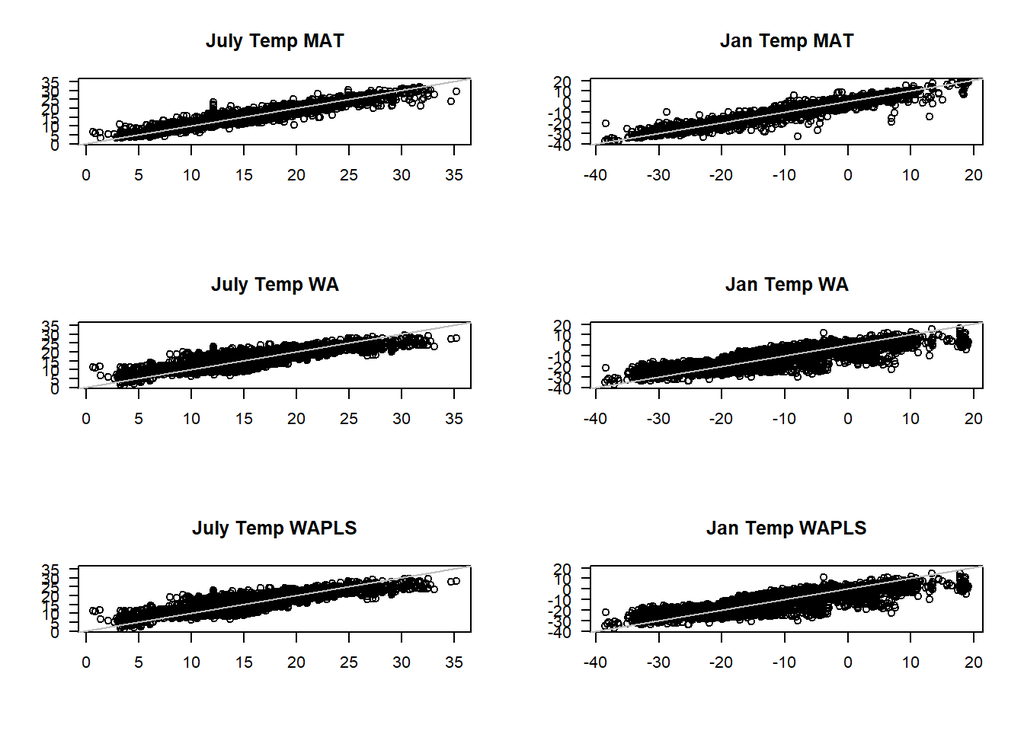

```r
layout(matrix(c(1,2,3,4,5,6), byrow = TRUE, ncol = 2))
plot(jul.mat.cal, main = "July Temp MAT")
plot(jan.mat.cal, main = "Jan Temp MAT")
plot(jul.wa.cal, main = "July Temp WA")
plot(jan.wa.cal, main = "Jan Temp WA")
plot(jul.wapls.cal, main = "July Temp WAPLS")
plot(jan.wapls.cal, main = "Jan Temp WAPLS")
```

**Reconstructions**

```r
jul.mat.pred <- predict(jul.mat.cal, fossil.per)
jan.mat.pred <- predict(jan.mat.cal, fossil.per)
jul.wa.pred <- predict(jul.wa.cal, fossil.per)
jan.wa.pred <- predict(jan.wa.cal, fossil.per)
jul.wapls.pred <- predict(jul.wapls.cal, fossil.per)
jan.wapls.pred <- predict(jan.wapls.cal, fossil.per)
jul.mat.pred
```

```
## $k
## [1] 5
##
## $fit
##          MAT   MAT.wm
## 127073 18.62 18.62140
## 127074 16.30 16.36293
## 127075 16.30 16.33384
## 127076 15.38 15.31426
## 127077 18.30 18.31507
## 127078 14.64 14.60755
## 127079 16.90 16.93558
## 127080 15.88 15.91003
## 127081 12.26 12.24622
## 127082 14.36 14.27614
```

[output cut: 177 more lines]

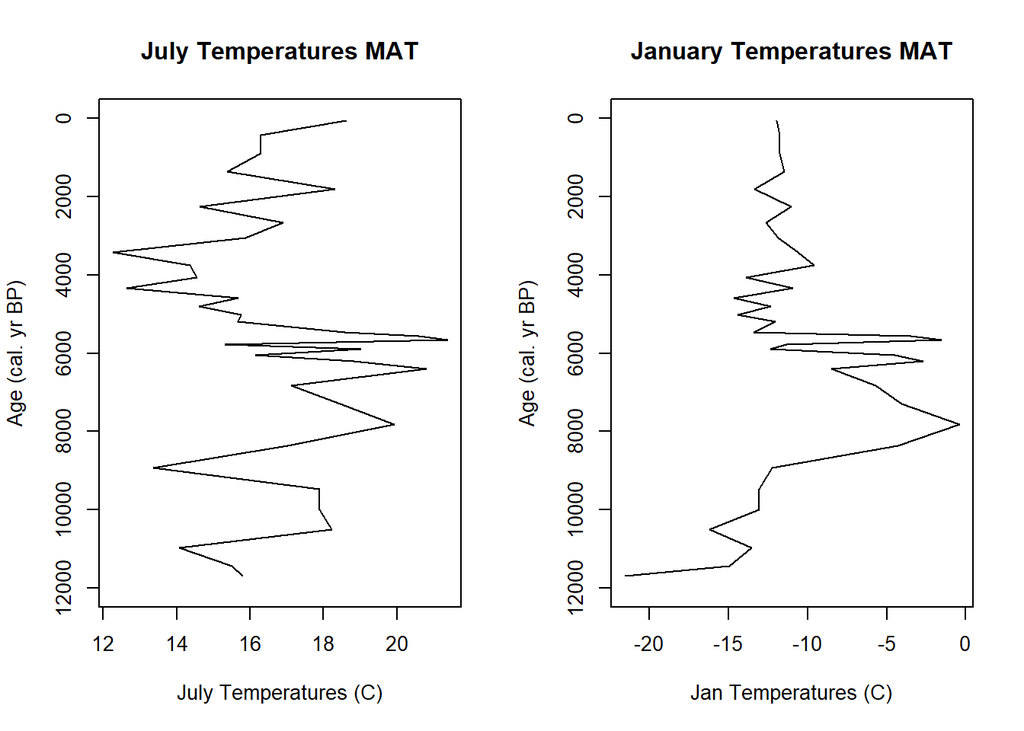

```r
#Let's plot the reconstructions
layout(matrix(c(1,2,1,2), byrow = TRUE, ncol = 2))
#Jul MAT
plot(ages ~ jul.mat.pred$fit[,1], type = 'l', ylim = c(12000,0), ylab = "Age (cal. yr BP)", xlab = "July Temperatures (C)", main =  "July Temperatures MAT")
#Jan Mat
plot(ages ~ jan.mat.pred$fit[,1], type = 'l', ylim = c(12000,0), ylab = "Age (cal. yr BP)", xlab = "Jan Temperatures (C)", main =  "January Temperatures MAT")
```

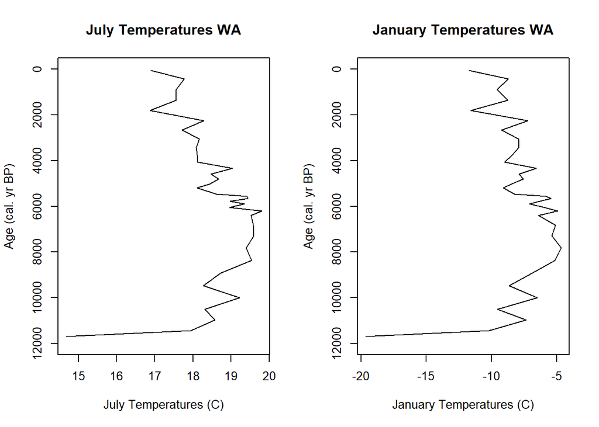

```r
#Jul WA
plot(ages ~ jul.wa.pred$fit[,1], type = 'l', ylim = c(12000,0), ylab = "Age (cal. yr BP)", xlab = "July Temperatures (C)", main =  "July Temperatures WA")
#Jan WA
plot(ages ~ jan.wa.pred$fit[,1], type = 'l', ylim = c(12000,0), ylab = "Age (cal. yr BP)", xlab = "January Temperatures (C)", main =  "January Temperatures WA")
```

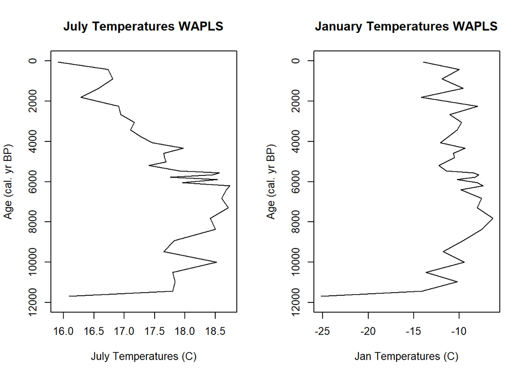

```r
#Jul WAPLS
plot(ages ~ jul.wapls.pred$fit[,2], type = 'l', ylim = c(12000,0), ylab = "Age (cal. yr BP)", xlab = "July Temperatures (C)", main =  "July Temperatures WAPLS")
#Jan WAPLS
plot(ages ~ jan.wapls.pred$fit[,2], type = 'l', ylim = c(12000,0), ylab = "Age (cal. yr BP)", xlab = "Jan Temperatures (C)", main =  "January Temperatures WAPLS")
```

All three transfer functions appear to agree with a general peak warming (both Jan and July) roughly 8000 years ago, with cooler temperatures ~12000 and present. WA and WAPLS agree more closely, and MAT shows some trends that do not agree with the other reconstructions (i.e. warming trend in July from 4000 to present). WAPLS showed the most extreme cold temperatures in January.

WA and WAPLS transfer functions are calculated in a way that’s similar than MAT, which explains the closer agreement between those models than between the MAT. Jan and July temperatures appear to be more in sync (in terms of relative change in temperature) in the WA and WAPLS models, while in MAT there are some discrepencies between the trends in the two. This is likely because WA’s calculate the species optima for each climate variable for the reconstruction, and since the same fossil set is used, we end up having a very similar pattern (as long as July and Jan temperatures are correlated in the modern set, the differences between species optima for pairs of species are similar for each month, and the ranges are similar for the same species between months). On the other hand, MAT uses distance from modern analogues, which may result in a situation where the similar assemblages can describe different climate conditions in the training set, and the magnitude of the differences between climate conditions explained by each analogue is different between months.

**Compare correlations between Jan and Jul temps for each reconstruction**

```r
#WA
wa.qual <- cbind(jan.wa.pred$fit[,1], jul.wa.pred$fit[,1])
colnames(wa.qual) <- c("Jan.Opt", "Jul.Opt")

#WAPLS
wapls.qual <- cbind(jan.wapls.pred$fit[,2], jul.wapls.pred$fit[,2])
colnames(wapls.qual) <- c("Jan.Opt", "Jul.Opt")
wapls.qual
```

```
##           Jan.Opt  Jul.Opt
## 127073 -13.959590 15.90564
## 127074 -10.023301 16.73601
## 127075 -11.922152 16.80938
## 127076  -9.584936 16.57986
## 127077 -14.169581 16.28130
## 127078  -8.007489 16.90582
## 127079 -11.033833 16.94262
## 127080  -9.737049 17.16295
## 127081 -10.242085 17.09879
## 127082 -11.177130 17.26074
## 127083 -12.054898 17.46199
## 127084  -9.366368 17.97245
## 127085 -10.645148 17.65157
## 127086 -10.518457 17.66424
```

[output cut: 21 more lines]

```r
#Let's compare the two
cor(wa.qual)
```

```
##           Jan.Opt   Jul.Opt
## Jan.Opt 1.0000000 0.9588976
## Jul.Opt 0.9588976 1.0000000
```

```r
cor(wapls.qual)
```

```
##           Jan.Opt   Jul.Opt
## Jan.Opt 1.0000000 0.6165468
## Jul.Opt 0.6165468 1.0000000
```

By evaluating the correlations between Jan and July temperature reconstructions for both the WAPLS and WA models we can conclude that the WAPLS transfer function appeared to have optima that were less correlated than our weighted averaging model.

```r
#MAT
mat.qual <- cbind(jan.mat.pred$diagnostics, jul.mat.pred$diagnostics)
colnames(mat.qual) <- c("Jan.Stdev", "Jan.minD", "Jul.StDev", "Jul.minD")
mat.qual
```

```
##         Jan.Stdev Jan.minD Jul.StDev Jul.minD
## 127073  1.9979990 28.02402 0.4764452 28.02402
## 127074  1.4170392 24.99841 3.3083228 24.99841
## 127075  1.4170392 26.12523 3.3083228 26.12523
## 127076  1.2660964 25.74539 3.2874002 25.74539
## 127077  1.1865918 25.57575 0.4415880 25.57575
## 127078  0.8734987 24.20336 2.7880100 24.20336
## 127079  2.0179197 26.09488 3.2163644 26.09488
## 127080  1.3608821 26.07787 3.6751871 26.07787
## 127081  2.6324893 17.90269 0.6767570 17.90269
## 127082  4.4941073 20.20884 3.7058063 20.20884
## 127083  4.4024993 22.42245 3.3170770 22.42245
## 127084  2.5304150 35.90493 1.3011533 35.90493
## 127085  3.6834766 22.79665 3.5414686 22.79665
## 127086  2.9065443 24.43378 3.4390406 24.43378
```

[output cut: 21 more lines]

The correlation between Jan and July temperatures in the MAT appears to be a 1 to 1 match. This indicates that the same analogues were used for both Jan and July temperatures. The difference in the temperature reconstructions for both months must be a result of similar assemblages being associated with different temperatures for each month, and those differences in temperatures between analogues having differences in magnitude in each model.

```r
cor(data.frame(mat.qual$Jan.Stdev, mat.qual$Jan.minD))
```

```
##                    mat.qual.Jan.Stdev mat.qual.Jan.minD
## mat.qual.Jan.Stdev          1.0000000        -0.1705791
## mat.qual.Jan.minD          -0.1705791         1.0000000
```

```r
cor(data.frame(mat.qual$Jul.StDev, mat.qual$Jul.minD))
```

```
##                    mat.qual.Jul.StDev mat.qual.Jul.minD
## mat.qual.Jul.StDev          1.0000000        -0.1542823
## mat.qual.Jul.minD          -0.1542823         1.0000000
```

Analgue quality (minimum Square Chord distance between the sample and the closest analogue) did not appear to have any discernable relationship to the sample standard deviation for either reconstruction.

```r
jan.mat.pred$match.name
```

```
##        N01    N02    N03    N04    N05
## 127073 "2"    "1649" "523"  "3806" "1650"
## 127074 "2"    "1649" "3382" "523"  "3395"
## 127075 "2"    "523"  "3395" "1649" "3382"
## 127076 "3395" "3378" "2"    "3382" "523"
## 127077 "523"  "1649" "2"    "1650" "3222"
## 127078 "3395" "3382" "2"    "3378" "3381"
## 127079 "523"  "2"    "1649" "3395" "3222"
## 127080 "1649" "2"    "3395" "523"  "355"
## 127081 "3395" "1360" "3396" "1358" "1359"
## 127082 "1360" "3395" "3396" "3382" "1350"
## 127083 "3222" "1360" "3396" "1549" "3395"
## 127084 "3395" "3396" "1360" "3382" "1358"
## 127085 "3396" "3395" "3222" "1549" "523"
## 127086 "3396" "3395" "1360" "3222" "2"
```

[output cut: 21 more lines]

```r
jul.mat.pred$match.name
```

```
##        N01    N02    N03    N04    N05
## 127073 "2"    "1649" "523"  "3806" "1650"
## 127074 "2"    "1649" "3382" "523"  "3395"
## 127075 "2"    "523"  "3395" "1649" "3382"
## 127076 "3395" "3378" "2"    "3382" "523"
## 127077 "523"  "1649" "2"    "1650" "3222"
## 127078 "3395" "3382" "2"    "3378" "3381"
## 127079 "523"  "2"    "1649" "3395" "3222"
## 127080 "1649" "2"    "3395" "523"  "355"
## 127081 "3395" "1360" "3396" "1358" "1359"
## 127082 "1360" "3395" "3396" "3382" "1350"
## 127083 "3222" "1360" "3396" "1549" "3395"
## 127084 "3395" "3396" "1360" "3382" "1358"
## 127085 "3396" "3395" "3222" "1549" "523"
## 127086 "3396" "3395" "1360" "3222" "2"
```

[output cut: 21 more lines]

$match.name shows that the same analogues were chosen for both Jan and July temperatures.

Let’s evaluate the correlations between all models

```r
all.cor <- data.frame(jul.mat.pred$fit[,1], jan.mat.pred$fit[,1], jul.wa.pred$fit[,1], jan.wa.pred$fit[,1], jul.wapls.pred$fit[,2], jan.wapls.pred$fit[,2])
colnames(all.cor) <- c("Jul.MAT", "Jan.MAT", "Jul.WA", "Jan.WA", "Jul.WAPLS", "Jan.WAPLS")
cor(all.cor)
```

```
##             Jul.MAT   Jan.MAT    Jul.WA    Jan.WA Jul.WAPLS Jan.WAPLS
## Jul.MAT   1.0000000 0.4546451 0.3017922 0.1920920 0.3886601 0.1401983
## Jan.MAT   0.4546451 1.0000000 0.7142970 0.7664151 0.5989288 0.7647449
## Jul.WA    0.3017922 0.7142970 1.0000000 0.9588976 0.9086219 0.8720830
## Jan.WA    0.1920920 0.7664151 0.9588976 1.0000000 0.7732847 0.9721166
## Jul.WAPLS 0.3886601 0.5989288 0.9086219 0.7732847 1.0000000 0.6165468
## Jan.WAPLS 0.1401983 0.7647449 0.8720830 0.9721166 0.6165468 1.0000000
```